# Hogan_popgen

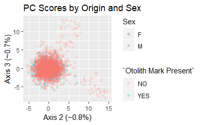

```r
ggplot(Scores_Attributes_odd, aes(x=Axis2, y=Axis3, color=`Otolith Mark Present`, shape=Sex)) +
  geom_point(alpha=0.2) +
  labs(title = "PC Scores by Origin and Sex", x="Axis 2 (~0.8%)", y="Axis 3 (~0.7%)")
```

For odd-year fish, axis 1 separates a small cluster of natural origin fish, which may be natural strays. Axes 2 and 3 also separate a small cluster of natural origin fish that appear to be a mix of males and females.

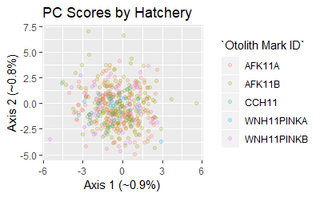

```r
Scores_Attributes_odd %>%
  filter(`Otolith Mark Present`=="YES") %>%
  ggplot(aes(x=Axis1, y=Axis2, color=`Otolith Mark ID`)) +
  geom_point(alpha=0.2) +
  labs(title="PC Scores by Hatchery", x="Axis 1 (~0.9%)", y="Axis 2 (~0.8%)")
```

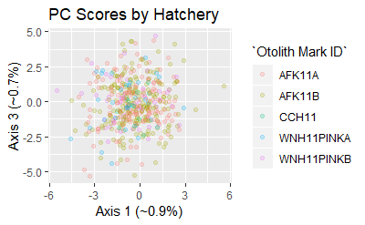

```r
Scores_Attributes_odd %>%
  filter(`Otolith Mark Present`=="YES") %>%
  ggplot(aes(x=Axis1, y=Axis3, color=`Otolith Mark ID`)) +
  geom_point(alpha=0.2) +
  labs(title="PC Scores by Hatchery", x="Axis 1 (~0.9%)", y="Axis 3 (~0.7%)")
```

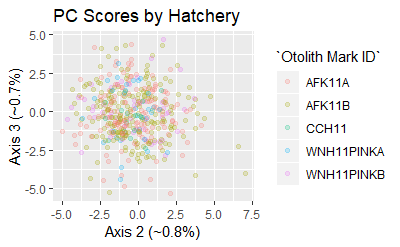

```r
Scores_Attributes_odd %>%
  filter(`Otolith Mark Present`=="YES") %>%
  ggplot(aes(x=Axis2, y=Axis3, color=`Otolith Mark ID`)) +
  geom_point(alpha=0.2) +
  labs(title="PC Scores by Hatchery", x="Axis 2 (~0.8%)", y="Axis 3 (~0.7%)")
```

Fish from different hatcheries appear intermixed.

```r
#Replace missing data.
Hogan_imputed_even <- scaleGen(Hogan_even, NA.method="mean")
class(Hogan_imputed_even)
```

```
[1] "matrix"
```

```r
dim(Hogan_imputed_even)
```

```
[1] 4680  661
```

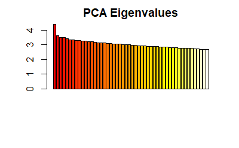

```r
pca_even <- dudi.pca(Hogan_imputed_even, cent=FALSE, scale=FALSE, scannf=FALSE, nf=3)
barplot(pca_even$eig[1:50], main="PCA Eigenvalues", col=heat.colors(50))
```

```r
summary(pca_even)
```

```
Class: pca dudi
Call: dudi.pca(df = Hogan_imputed_even, center = FALSE, scale = FALSE,
    scannf = FALSE, nf = 3)

Total inertia: 660.9

Eigenvalues:
    Ax1     Ax2     Ax3     Ax4     Ax5
  4.408   3.618   3.520   3.490   3.436

Projected inertia (%):
    Ax1     Ax2     Ax3     Ax4     Ax5
 0.6670  0.5475  0.5326  0.5281  0.5199

Cumulative projected inertia (%):
    Ax1   Ax1:2   Ax1:3   Ax1:4   Ax1:5
  0.667   1.215   1.747   2.275   2.795

(Only 5 dimensions (out of 357) are shown)
```

These are eigenvalues for a PCA including only even-year fish. These values are similar to what we observed for the odd-year lineage.

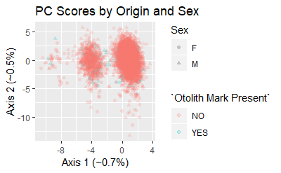

```r
Scores_Attributes_even <- pca_even$li %>%
  as_tibble(rownames="silly_source") %>%
  left_join(HOGAN_attributes_even_tibble, by=c("silly_source"= "SillySource"))
ggplot(Scores_Attributes_even, aes(x=Axis1, y=Axis2, color=`Otolith Mark Present`, shape=Sex)) +
  geom_point(alpha=0.2) +
  labs(title = "PC Scores by Origin and Sex", x="Axis 1 (~0.7%)", y="Axis 2 (~0.5%)")
```

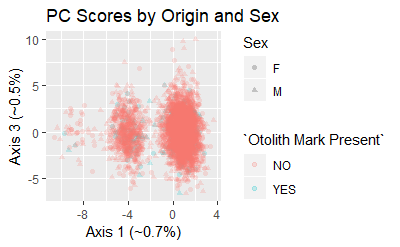

```r
ggplot(Scores_Attributes_even, aes(x=Axis1, y=Axis3, color=`Otolith Mark Present`, shape=Sex)) +
  geom_point(alpha=0.2) +
  labs(title = "PC Scores by Origin and Sex", x="Axis 1 (~0.7%)", y="Axis 3 (~0.5%)")
```

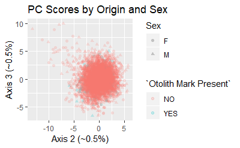

```r
ggplot(Scores_Attributes_even, aes(x=Axis2, y=Axis3, color=`Otolith Mark Present`, shape=Sex)) +
  geom_point(alpha=0.2) +
  labs(title = "PC Scores by Origin and Sex", x="Axis 2 (~0.5%)", y="Axis 3 (~0.5%)")
```

Let’s examine loadings again.

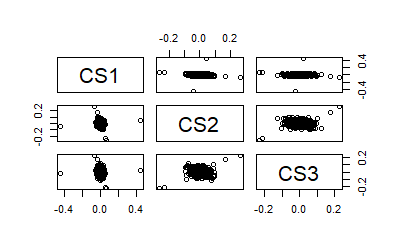

It appears that the banding is again driven by a small number of outlier loci.

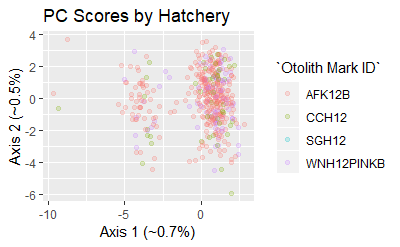

```r
Scores_Attributes_even %>%
  filter(`Otolith Mark Present`=="YES") %>%
  ggplot(aes(x=Axis1, y=Axis2, color=`Otolith Mark ID`)) +
  geom_point(alpha=0.2) +
  labs(title="PC Scores by Hatchery", x="Axis 1 (~0.7%)", y="Axis 2 (~0.5%)")
```

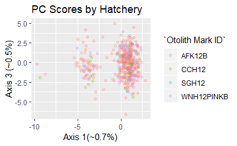

```r
Scores_Attributes_even %>%
  filter(`Otolith Mark Present`=="YES") %>%
  ggplot(aes(x=Axis1, y=Axis3, color=`Otolith Mark ID`)) +
  geom_point(alpha=0.2) +
  labs(title="PC Scores by Hatchery", x="Axis 1(~0.7%)", y="Axis 3 (~0.5%)")
```

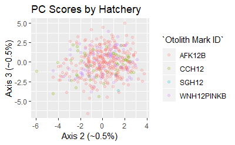

```r
Scores_Attributes_even %>%
  filter(`Otolith Mark Present`=="YES") %>%
  ggplot(aes(x=Axis2, y=Axis3, color=`Otolith Mark ID`)) +
  geom_point(alpha=0.2) +
  labs(title="PC Scores by Hatchery", x="Axis 2 (~0.5%)", y="Axis 3 (~0.5%)")
```

Again, axis 1 seems to separate the fish into clusters, although fish do not cluster by hatchery.

```r
aov_even <- aov(Scores_Attributes_even$Axis1~Scores_Attributes_even$SILLY_CODE*Scores_Attributes_even$Sex*Scores_Attributes_even$`Otolith Mark Present`)
summary(aov_even)
```

```
                                                                           Df Sum Sq Mean Sq F value Pr(>F)
Scores_Attributes_even$SILLY_CODE                                           1      1   0.585   0.133  0.716
Scores_Attributes_even$Sex                                                  1      1   0.714   0.162  0.687
Scores_Attributes_even$`Otolith Mark Present`                               1      0   0.140   0.032  0.858
Scores_Attributes_even$SILLY_CODE:Scores_Attributes_even$Sex                1      3   3.015   0.684  0.408
Scores_Attributes_even$Sex:Scores_Attributes_even$`Otolith Mark Present`    1      7   7.481   1.696  0.193
Residuals                                                                4674  20618   4.411
```

Despite apparent clustering along axis 1, there are no significant differences in Axis 1 scores due to year, sex, origin, or interactions.

## Examine Linkage Disequilibrium among Loci

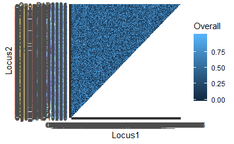

Plot of overall LD. The heatmap is unfortunately pretty indecipherable due to the large number of pairwise comparisons. Because of this, I filtered the dataframe below to only include loci with significant linkage (p<0.05).

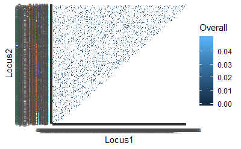

Plot of markers with significant LD (p<0.05). About 1/10 of the comparisons were significant. We can return to this list of loci later if we need to after we’ve tested the power of our marker set.

# Main take-aways:

The remaining mystery seems to be explaining the outgroup in Axes 2 and 3. They appear to be natural-origin strays.

# Convert GenePop file to Franz format for parentage analysis

```r
genepop2franz.GCL("../Genepop/hogan_postQA.gen", "../OceanAK/AHRP - Salmon Biological Data 2_PWS_2013-2017_no_otoliths.csv", c(2013, 2016), "HOGAN", "../")
```

```
 Converting data from a Genepop .gen file to a genind object...


File description:  GENEPOP input format

...done.
```

```r
genepop2franz.GCL("../Genepop/hogan_postQA.gen", "../OceanAK/AHRP - Salmon Biological Data 2_PWS_2013-2017_no_otoliths.csv", c(2014, 2015), "HOGAN", "../")
```

```
 Converting data from a Genepop .gen file to a genind object...


File description:  GENEPOP input format

...done.
```

Note that we had to make separate files for even and odd lineages. We also created two files that we’ll use to calculate error rates. These contain mismatched parent-offspring years (2013 and 2016 as well as 2014 and 2015). We kept the parental and offspring assignments consistent (e.g. in all files 2013 and 2014 are parental years and 2015 and 2016 are offspring years). Note that we need to manually modify years in the 2013-2016 file, otherwise the parents would all be dead before any of the offspring were born.